# SR_04_RLTD_ORG_CORP_ADDR_STATE

Related organization state · Code report

## Overview

**Description**

Province or state

**Table**

`SR-P04-T01-ID-RLTD-ORGS-TAXABLE-CORPORATION` (many)

**Location code**

`SCHED-R-PART-04-COL-A`

**Family**

`SCHED-R-PART-04-COL-A` · siblings: SR_04_RLTD_ORG_CORP_ADDR_CITY, SR_04_RLTD_ORG_CORP_ADDR_CNTR, SR_04_RLTD_ORG_CORP_ADDR_L1, SR_04_RLTD_ORG_CORP_ADDR_L2, SR_04_RLTD_ORG_CORP_ADDR_ZIP, SR_04_RLTD_ORG_CORP_EIN

**Data type**

text (xsd: TextType, StateType)

**Scope**

PC

**Status**

unreviewed

6

xpaths mapped (6 observed)

254,645

filings with a value

2009–2024

tax years observed

1

open flags (1 errors)

## Flags

| Severity | Flag | Xpath | Detail |
| --- | --- | --- | --- |
| ⚠ error | `COLLISION` | IRS990ScheduleR/IdRelatedOrgTxblCorpTrGrp/ForeignAddress/ProvinceOrStateNm | 14854 filings contain 2+ of its xpaths; most common set: /Return/ReturnData/IRS990ScheduleR/IdRelatedOrgTxblCorpTrGrp/ForeignAddress/ProvinceOrStateNm ; /Return/ReturnData/IRS990ScheduleR/IdRelatedOrg… |

## Xpaths

All mapped xpaths (under /Return/ReturnData or /Return/ReturnHeader), oldest first. Charts label each series by its xpath.

| Xpath | Form | Chart label | First year | Last year | Versions | Filings | Repeats in |
| --- | --- | --- | --- | --- | --- | --- | --- |
| IRS990ScheduleR/Form990ScheduleRPartIV/AddressUS/State | Sched R | same | 2009 | 2012 | 17 | 40,944 | 51.8% |
| IRS990ScheduleR/Form990ScheduleRPartIV/AddressForeign/ProvinceOrState | Sched R | …leR/Form990ScheduleRPartIV/AddressForeign/ProvinceOrState | 2009 | 2012 | 14 | 3,258 | 24.2% |
| IRS990ScheduleR/IdRelatedOrgTxblCorpTrGrp/USAddress/State | Sched R | same | 2013 | 2013 | 3 | 14,114 | 50.3% |
| IRS990ScheduleR/IdRelatedOrgTxblCorpTrGrp/ForeignAddress/ProvinceOrState | Sched R | …/IdRelatedOrgTxblCorpTrGrp/ForeignAddress/ProvinceOrState | 2013 | 2013 | 3 | 1,169 | 23.0% |
| IRS990ScheduleR/IdRelatedOrgTxblCorpTrGrp/USAddress/StateAbbreviationCd | Sched R | …R/IdRelatedOrgTxblCorpTrGrp/USAddress/StateAbbreviationCd | 2014 | 2024 | 34 | 182,343 | 51.0% |
| IRS990ScheduleR/IdRelatedOrgTxblCorpTrGrp/ForeignAddress/ProvinceOrStateNm | Sched R | …dRelatedOrgTxblCorpTrGrp/ForeignAddress/ProvinceOrStateNm | 2014 | 2024 | 32 | 12,817 | 47.2% |

## Coverage

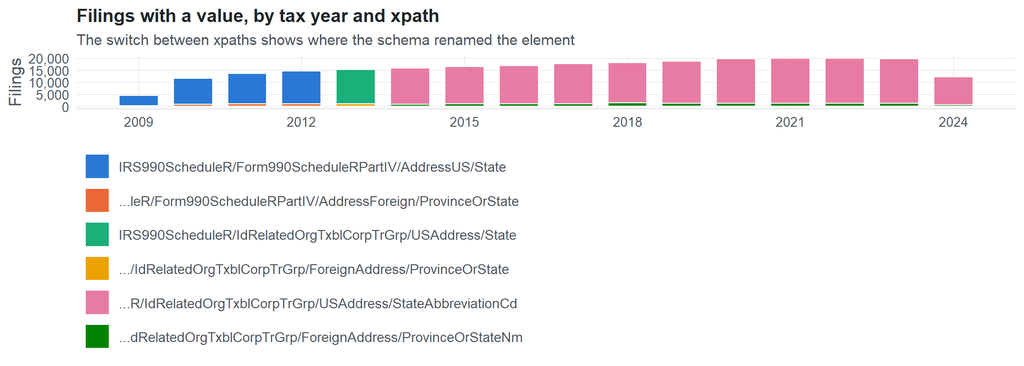

**Table view**

Table view: filings by tax year and series

| Tax year | IRS990ScheduleR/Form990ScheduleRPartIV/AddressUS/State | …leR/Form990ScheduleRPartIV/AddressForeign/ProvinceOrState | IRS990ScheduleR/IdRelatedOrgTxblCorpTrGrp/USAddress/State | …/IdRelatedOrgTxblCorpTrGrp/ForeignAddress/ProvinceOrState | …R/IdRelatedOrgTxblCorpTrGrp/USAddress/StateAbbreviationCd | …dRelatedOrgTxblCorpTrGrp/ForeignAddress/ProvinceOrStateNm |
| --- | --- | --- | --- | --- | --- | --- |
| 2009 | 4,167 | 269 | 0 | 0 | 0 | 0 |
| 2010 | 10,720 | 851 | 0 | 0 | 0 | 0 |
| 2011 | 12,659 | 986 | 0 | 0 | 0 | 0 |
| 2012 | 13,398 | 1,152 | 0 | 0 | 0 | 0 |
| 2013 | 0 | 0 | 14,114 | 1,169 | 0 | 0 |
| 2014 | 0 | 0 | 0 | 0 | 14,930 | 950 |
| 2015 | 0 | 0 | 0 | 0 | 15,444 | 994 |
| 2016 | 0 | 0 | 0 | 0 | 15,775 | 1,020 |
| 2017 | 0 | 0 | 0 | 0 | 16,561 | 1,145 |
| 2018 | 0 | 0 | 0 | 0 | 16,741 | 1,409 |
| 2019 | 0 | 0 | 0 | 0 | 17,305 | 1,318 |
| 2020 | 0 | 0 | 0 | 0 | 18,341 | 1,371 |
| 2021 | 0 | 0 | 0 | 0 | 18,550 | 1,351 |
| 2022 | 0 | 0 | 0 | 0 | 18,640 | 1,341 |
| 2023 | 0 | 0 | 0 | 0 | 18,431 | 1,333 |
| 2024 | 0 | 0 | 0 | 0 | 11,625 | 585 |

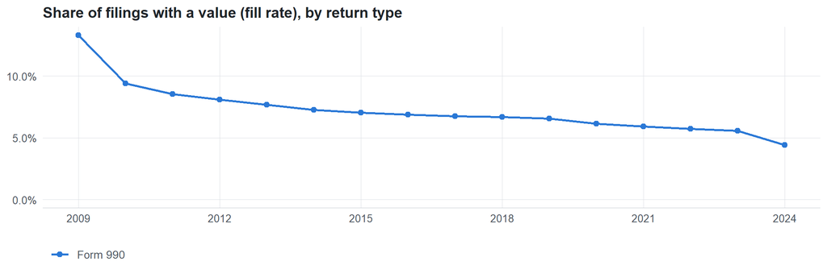

**Table view**

Table view: fill rate

| Tax year | Return type | Filings | All filings | Fill rate |
| --- | --- | --- | --- | --- |
| 2009 | Form 990 | 4,436 | 33,311 | 13.32% |
| 2010 | Form 990 | 11,571 | 123,025 | 9.41% |
| 2011 | Form 990 | 13,645 | 159,504 | 8.55% |
| 2012 | Form 990 | 14,550 | 179,688 | 8.10% |
| 2013 | Form 990 | 15,283 | 198,855 | 7.69% |
| 2014 | Form 990 | 15,880 | 218,619 | 7.26% |
| 2015 | Form 990 | 16,438 | 233,519 | 7.04% |
| 2016 | Form 990 | 16,795 | 243,903 | 6.89% |
| 2017 | Form 990 | 17,706 | 261,612 | 6.77% |
| 2018 | Form 990 | 18,150 | 271,442 | 6.69% |
| 2019 | Form 990 | 18,623 | 283,694 | 6.56% |
| 2020 | Form 990 | 19,712 | 320,342 | 6.15% |
| 2021 | Form 990 | 19,901 | 336,480 | 5.91% |
| 2022 | Form 990 | 19,981 | 349,055 | 5.72% |
| 2023 | Form 990 | 19,764 | 354,768 | 5.57% |
| 2024 | Form 990 | 12,210 | 277,298 | 4.40% |

## Repeating groups

Table cardinality in the concordance: **many**. 6 of 6 observed xpaths repeat within a filing.

Repeating element each xpath was observed in (from the raw indexed xpath)

| Xpath | Repeating element | Filings (summed over years) |
| --- | --- | --- |
| IRS990ScheduleR/Form990ScheduleRPartIV/AddressForeign/ProvinceOrState | (none) | 222 |
| IRS990ScheduleR/Form990ScheduleRPartIV/AddressForeign/ProvinceOrState | IRS990ScheduleR/Form990ScheduleRPartIV | 3036 |
| IRS990ScheduleR/Form990ScheduleRPartIV/AddressUS/State | (none) | 18843 |
| IRS990ScheduleR/Form990ScheduleRPartIV/AddressUS/State | IRS990ScheduleR/Form990ScheduleRPartIV | 22101 |
| IRS990ScheduleR/IdRelatedOrgTxblCorpTrGrp/ForeignAddress/ProvinceOrState | (none) | 70 |
| IRS990ScheduleR/IdRelatedOrgTxblCorpTrGrp/ForeignAddress/ProvinceOrState | IRS990ScheduleR/IdRelatedOrgTxblCorpTrGrp | 1099 |
| IRS990ScheduleR/IdRelatedOrgTxblCorpTrGrp/USAddress/State | (none) | 6705 |
| IRS990ScheduleR/IdRelatedOrgTxblCorpTrGrp/USAddress/State | IRS990ScheduleR/IdRelatedOrgTxblCorpTrGrp | 7409 |
| IRS990ScheduleR/IdRelatedOrgTxblCorpTrGrp/ForeignAddress/ProvinceOrStateNm | (none) | 1052 |
| IRS990ScheduleR/IdRelatedOrgTxblCorpTrGrp/ForeignAddress/ProvinceOrStateNm | IRS990ScheduleR/IdRelatedOrgTxblCorpTrGrp | 11765 |
| IRS990ScheduleR/IdRelatedOrgTxblCorpTrGrp/USAddress/StateAbbreviationCd | (none) | 85289 |
| IRS990ScheduleR/IdRelatedOrgTxblCorpTrGrp/USAddress/StateAbbreviationCd | IRS990ScheduleR/IdRelatedOrgTxblCorpTrGrp | 97054 |

## Values

| Result | Check | Detail |
| --- | --- | --- |
| ▲ warn | Small code list | up to 407 distinct values per xpath and year |
| ▲ warn | Codes share one format | 94% have the shape AA |
| ✓ pass | Consistent letter case | 0.0% of values are lower case |

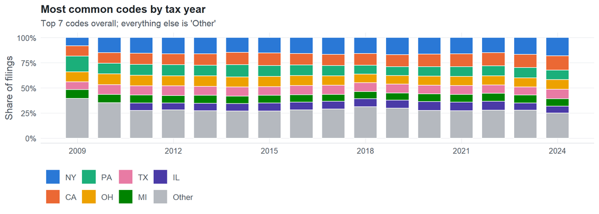

**Table view**

Table view: filings by code and tax year

| tax_year | NY | CA | PA | OH | TX | MI | IL | Other |
| --- | --- | --- | --- | --- | --- | --- | --- | --- |
| 2009 | 266 | 333 | 514 | 324 | 259 | 290 | 0 | 1,289 |
| 2010 | 1,301 | 916 | 890 | 941 | 834 | 730 | 0 | 3,034 |
| 2011 | 1,736 | 1,226 | 1,208 | 1,182 | 993 | 895 | 826 | 3,069 |
| 2012 | 1,899 | 1,279 | 1,301 | 1,163 | 1,137 | 863 | 810 | 3,313 |
| 2013 | 2,007 | 1,406 | 1,295 | 1,283 | 1,108 | 972 | 911 | 3,371 |
| 2014 | 1,899 | 1,620 | 1,559 | 1,299 | 1,194 | 968 | 973 | 3,497 |
| 2015 | 2,015 | 1,661 | 1,451 | 1,329 | 1,158 | 1,013 | 1,034 | 3,591 |
| 2016 | 2,180 | 1,552 | 1,455 | 1,355 | 1,267 | 1,027 | 1,051 | 3,850 |
| 2017 | 2,475 | 1,626 | 1,519 | 1,413 | 1,326 | 1,023 | 1,144 | 4,272 |
| 2018 | 2,743 | 2,004 | 1,508 | 1,479 | 1,511 | 1,243 | 1,371 | 5,373 |
| 2019 | 3,015 | 2,153 | 1,596 | 1,504 | 1,568 | 1,264 | 1,426 | 5,339 |
| 2020 | 2,846 | 2,174 | 1,614 | 1,590 | 1,478 | 1,312 | 1,510 | 4,774 |
| 2021 | 2,723 | 2,205 | 1,654 | 1,522 | 1,493 | 1,317 | 1,461 | 4,612 |
| 2022 | 2,551 | 2,187 | 1,687 | 1,520 | 1,400 | 1,369 | 1,453 | 4,709 |
| 2023 | 2,747 | 2,169 | 1,669 | 1,503 | 1,304 | 1,306 | 1,151 | 4,594 |
| 2024 | 1,632 | 1,297 | 830 | 870 | 845 | 683 | 617 | 2,247 |

Code frequencies (all xpaths, all years)

| Code | Filings | Share |
| --- | --- | --- |
| NY | 34,035 | 15.9% |
| CA | 25,808 | 12.1% |
| PA | 21,750 | 10.2% |
| OH | 20,277 | 9.5% |
| TX | 18,875 | 8.8% |
| MI | 16,275 | 7.6% |
| IL | 15,738 | 7.4% |
| FL | 14,040 | 6.6% |
| MD | 11,649 | 5.5% |
| MA | 7,352 | 3.4% |
| GRAND CAYMAN | 5,998 | 2.8% |
| MO | 4,675 | 2.2% |
| NJ | 4,040 | 1.9% |
| WI | 2,561 | 1.2% |
| ENGLAND | 1,500 | 0.7% |
| Bahamas | 1,483 | 0.7% |
| CAYMAN ISLANDS | 1,250 | 0.6% |
| Grand Cayman | 1,115 | 0.5% |
| VA | 1,073 | 0.5% |
| BERMUDA | 947 | 0.4% |
| Cayman Islands | 584 | 0.3% |
| IA | 251 | 0.1% |
| Hamilton | 226 | 0.1% |
| HAMILTON | 208 | 0.1% |
| BEIJING | 192 | 0.1% |
| BC | 181 | 0.1% |
| ONTARIO | 168 | 0.1% |
| BRISTOL | 164 | 0.1% |
| Ontario | 149 | 0.1% |
| BERMUDA HMHX | 95 | 0.0% |

First rows shown.

## Examples

| Tax year | Return | Xpath | Organization | Value | Source |
| --- | --- | --- | --- | --- | --- |
| 2024 | 990 | IRS990ScheduleR/IdRelatedOrgTxblCorpTrGrp/ForeignAddress/ProvinceOrStateNm | CONCUSSION LEGACY FOUNDATION INC | WALES | [XML](https://gt990datalake-rawdata.s3.amazonaws.com/EfileData/XmlFiles/202533189349301693_public.xml) |
| 2024 | 990 | IRS990ScheduleR/IdRelatedOrgTxblCorpTrGrp/USAddress/StateAbbreviationCd | PENNSYLVANIA INSTITUTE OF TECHNOLOGY | PA | [XML](https://gt990datalake-rawdata.s3.amazonaws.com/EfileData/XmlFiles/202641119349301809_public.xml) |
| 2023 | 990 | IRS990ScheduleR/IdRelatedOrgTxblCorpTrGrp/ForeignAddress/ProvinceOrStateNm | DAVIS HEALTH SYSTEM FOUNDATION INC | CAYMAN ISLANDS | [XML](https://gt990datalake-rawdata.s3.amazonaws.com/EfileData/XmlFiles/202413199349319366_public.xml) |
| 2023 | 990 | IRS990ScheduleR/IdRelatedOrgTxblCorpTrGrp/USAddress/StateAbbreviationCd | AK Steel Corp VEBA UAW Retirees | OH | [XML](https://gt990datalake-rawdata.s3.amazonaws.com/EfileData/XmlFiles/202442269349300844_public.xml) |
| 2022 | 990 | IRS990ScheduleR/IdRelatedOrgTxblCorpTrGrp/ForeignAddress/ProvinceOrStateNm | St Mark’s Medical Center | GRAND CAYMAN | [XML](https://gt990datalake-rawdata.s3.amazonaws.com/EfileData/XmlFiles/202411319349303601_public.xml) |
| 2022 | 990 | IRS990ScheduleR/IdRelatedOrgTxblCorpTrGrp/USAddress/StateAbbreviationCd | THE GOOD SHEPHERD HOME FOR THE AGED INC | OH | [XML](https://gt990datalake-rawdata.s3.amazonaws.com/EfileData/XmlFiles/202401089349300430_public.xml) |
| 2021 | 990 | IRS990ScheduleR/IdRelatedOrgTxblCorpTrGrp/ForeignAddress/ProvinceOrStateNm | St John Providence | ENGLAND | [XML](https://gt990datalake-rawdata.s3.amazonaws.com/EfileData/XmlFiles/202311329349304191_public.xml) |
| 2021 | 990 | IRS990ScheduleR/IdRelatedOrgTxblCorpTrGrp/USAddress/StateAbbreviationCd | St John Providence | MO | [XML](https://gt990datalake-rawdata.s3.amazonaws.com/EfileData/XmlFiles/202311329349304191_public.xml) |
| 2020 | 990 | IRS990ScheduleR/IdRelatedOrgTxblCorpTrGrp/ForeignAddress/ProvinceOrStateNm | GEISINGER SYSTEM SERVICES | GRAND CAYMAN | [XML](https://gt990datalake-rawdata.s3.amazonaws.com/EfileData/XmlFiles/202143169349304724_public.xml) |
| 2020 | 990 | IRS990ScheduleR/IdRelatedOrgTxblCorpTrGrp/USAddress/StateAbbreviationCd | The CareSource Foundation | OH | [XML](https://gt990datalake-rawdata.s3.amazonaws.com/EfileData/XmlFiles/202123169349306582_public.xml) |
| 2019 | 990 | IRS990ScheduleR/IdRelatedOrgTxblCorpTrGrp/ForeignAddress/ProvinceOrStateNm | Northwestern University | Grand Cayman | [XML](https://gt990datalake-rawdata.s3.amazonaws.com/EfileData/XmlFiles/202141959349301014_public.xml) |
| 2019 | 990 | IRS990ScheduleR/IdRelatedOrgTxblCorpTrGrp/USAddress/StateAbbreviationCd | ALEXANDRIA SENIOR HOUSING INC | MN | [XML](https://gt990datalake-rawdata.s3.amazonaws.com/EfileData/XmlFiles/202033189349302573_public.xml) |

## Reviewer checklist

- The definition matches the form line and instructions for every xpath’s schema years.
- Every xpath pooled here measures the same thing on the 990 and 990-EZ (close enough for analysis).
- The coverage chart has no unexplained gaps or jumps between tax years.
- Each open flag is fixed, or accepted with a note in validation_log.csv.
- Every code is valid for the list the form uses (state, country, valuation method, …).
- The code list and its meaning did not change across schema versions.
- Codes are stored as text, so values like leading zeros are preserved.

Record the review as a row in `inst/extdata/src/validation_log.csv` (variable_name, reviewer, date, status, note). Evidence built 2026-09-23 17:09:04 MST from the ef2 DuckDB builds (tax years 2009–2024).